# 05_Use_Case_Diagrams

## Use Case діаграми.

**Use Case діаграма** (Діаграма варіантів використання/прецедентів) представляє функціональність системи за рахунок використання суб’єктів (акторів) та варіантів використання.

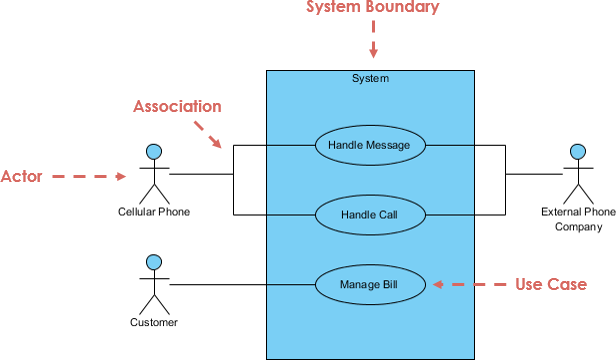

**Використовується** для подання динамічної поведінки системи. Для моделювання недостатньо лише статичної поведінки.

**Моделює** завдання, служби та функції, необхідні для системи/підсистеми програми.

**Відображає** високорівневу функціональність системи, а також розповідає, як користувач поводиться з системою.

**Use Case діаграма є** типом поведінкової діаграми UML, який часто використовується для аналізу різних систем. Вона дозволяє візуалізувати різні типи ролей у системі та те, як ці ролі взаємодіють із системою.

**Призначення Use Case діаграми:**

- Визначення контексту та вимог системи.
- Використовується для отримання зовнішнього огляду системи. Можна виділити ролі, які взаємодіють із системою, та функції, що надаються системою, не заглиблюючись у внутрішню роботу системи.
- Визначає зовнішні та внутрішні фактори, що впливають на систему. Ці внутрішні та зовнішні фактори можуть бути представлені як актори.
- Моделювання основного потоку подій у варіанті використання. Описується один основний потік подій (основні сценарії) і, можливо, інші виняткові потоки (альтернативи), також звані шляхами або сценаріями користувача.

**Об’єкти Use Case діаграми:**

- Актор (актор).
- Use case (варіант використання/прецедент).
- Associations (асоціації).
- System/Boundary of system (система/рамки системи).
- Packages (пакети).

**Актор (актор).** Будь-який об’єкт, який виконує роль однієї даної системі. Це може бути людина, організація чи зовнішня система. Подібно до концепції користувача, але користувач може грати різні ролі.

**Use case (варіант використання/прецедент).** Представляє функцію чи дію у системі.

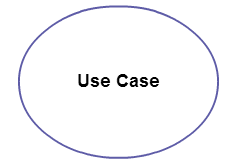

**Associations (асоціації).** Лінія зв’язку між учасниками та варіантами використання. У складних діаграмах важливо знати, які суб’єкти пов’язані з якими варіантами використання.

**System/Boundary of system (система/рамки системи).** Використовується для визначення рамок варіанта використання. Це потенційно вся система відповідно до вимог.

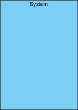

**Packages (пакети).** Використовуються для угрупування варіантів використання.

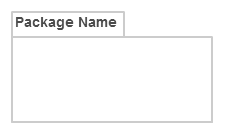

**Відносини в Use Case діаграмах:**

- Асоціація між актором та варіантом використання.
- Узагальнення актора.
- Розширення відносин між двома варіантами використання.
- Включення взаємозв’язку між двома варіантами використання.
- Узагальнення варіанта використання.

**Асоціація (Association) між** актором і варіантом використання:

- Актор має бути пов’язаний хоч би з одним варіантом використання.
- Актор може бути пов’язаний із декількома варіантами використання.
- Декілька акторів можуть бути пов’язані з одним варіантом використання.

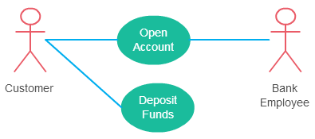

**Узагальнення (Generalization) актора.** Один актор може успадкувати роль іншого актора. Нащадок успадковує всі варіанти використання предка. Нащадок має один або кілька варіантів використання, специфічних для цієї ролі. NRFC (Non Resident Foreign Currency).

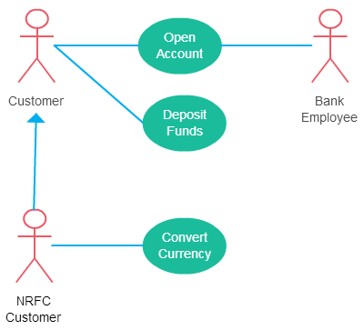

**Розширення (Extend) відносин** між двома варіантами використання. Розширення базового варіанта використання та додавання системі більше функціональних можливостей.

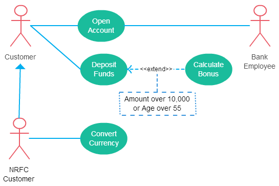

Розширюючий варіант використання залежить від розширеного (базового) варіанта використання. На діаграмі, варіант використання «Розрахунок бонусу» не має великого сенсу без варіанта використання «Внести кошти».

Розширюючий варіант використання зазвичай необов’язковий і може бути запущений умовно. На діаграмі, що розширює варіант використання, запускається тільки для депозитів більше 10 000 або коли вік перевищує 55.

Розширений (базовий) варіант використання повинен мати сенс сам собою. Має бути незалежним і не повинен покладатися на поведінку розширюючого варіанта використання.

**Включення (Include) взаємозв’язку** між двома варіантами використання. Поведінка включеного варіанта використання є частиною включаючого (базового) варіанта використання. Основна причина – багаторазове використання спільних дій у кількох сценаріях використання. У деяких ситуаціях це робиться для спрощення складних форм поведінки.

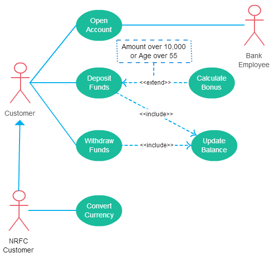

Включення (Include):

- Базовий варіант використання неповний без включеного варіанта використання.
- Включений варіант використання є обов’язковим, а не додатковим.

**Узагальнення (Generalization) варіанта** використання схоже на узагальнення актора. Поведінка предка успадковується нащадком. Використовується, коли існує загальна поведінка між двома варіантами використання, а також особлива поведінка, специфічна для кожного варіанту використання.

У прикладі банківського обслуговування можливий варіант використання під назвою «Оплата рахунків». Це можна узагальнити на «Оплата кредитною карткою», «Оплата з банківського рахунку» і т.і.

**Створення Use Case діаграми.**

**Виявлення акторів**. Актори – зовнішні сутності, які взаємодіють із системою. Це може бути людина, інша система чи організація. У банківській системі найбільш очевидною дійовою особою є клієнт. Інші учасники можуть бути співробітником банку або касиром залежно від ролі у сценарії використання.

**Виявлення варіантів використання.** Визначити, що учасникам потрібно від системи. У банківській системі клієнту необхідно буде відкривати рахунки, вносити та знімати кошти та виконувати аналогічні функції. Усе це можна розглядати як варіанти використання.

**Визначення спільних функцій для використання включення.** Загальні функції, які можна повторно використовувати у системі. Якщо ви знайдете два або більше варіантів використання, які мають спільні функції, ви можете вилучити спільні функції та додати їх до окремого варіанту використання. Потім можете підключити його через відношення include, щоб показати, що він завжди викликається при виконанні вихідного варіанта використання.

**Виявлення можливостей узагальнення акторів та варіантів використання.** Можуть бути випадки, коли суб’єкти пов’язані з аналогічними варіантами використання, при цьому запускаються кілька варіантів використання, унікальних лише їм. У таких випадках можете узагальнити актора, щоб показати успадкування функцій. Можете зробити те саме і для варіантів використання.

**Додаткові функції.** Деякі функції запускаються опціонально. У таких випадках можна використовувати відношення розширення. У прикладі банківської системи, «Розрахунок бонусу» є необов’язковим і спрацьовує тільки при дотриманні певної умови.